# Customizing ggplot

Kim Dill-McFarland, kadm@uw.edu

version January 18, 2022

# Overview

In this workshop, we explore some options to customize ggplot. This document contains the basic plot to start and then addtional plots with modifications in response to attendee questions.

# Prior to the workshop

Please install [R](http://www.r-project.org), [RStudio](https://www.rstudio.com/products/rstudio/download/), and the following packages.

```r
#Data manipulation
#install.packages("tidyverse")
library(tidyverse)
#Example data
#install.packages("devtools")
#devtools::install_github("BIGslu/kimma")
library(kimma)
```

# Load data

We combine the expression, sample, and gene metadata in a single table for use in plotting.

```r
dat <- as.data.frame(example.voom$E) %>%
  rownames_to_column("geneName") %>%
  pivot_longer(-geneName, names_to = "libID") %>%
  inner_join(example.voom$targets, by = "libID") %>%
  inner_join(example.voom$genes, by = "geneName")

dat
```

```
## # A tibble: 12,000 × 15
##    geneName     libID value group lib.size norm.factors donorID median_cv_cover…
##    <chr>        <chr> <dbl> <fct>    <dbl>        <dbl> <chr>              <dbl>
##  1 ENSG0000000… lib1   6.11 1       79646.        1.00  donor1             0.514
##  2 ENSG0000000… lib2   8.00 1       88008.        0.951 donor1             0.435
##  3 ENSG0000000… lib3   7.32 1      178020.        1.09  donor2             0.374
##  4 ENSG0000000… lib4   7.33 1      133836.        0.943 donor2             0.388
##  5 ENSG0000000… lib5   7.92 1      192547.        1.00  donor3             0.353
##  6 ENSG0000000… lib6   7.99 1      175144.        0.974 donor3             0.349
##  7 ENSG0000000… lib7   8.29 1      205377.        1.02  donor4             0.339
##  8 ENSG0000000… lib8   8.05 1      149311.        0.995 donor4             0.350
##  9 ENSG0000000… lib9   7.13 1      182080.        1.04  donor5             0.342
## 10 ENSG0000000… lib10  8.58 1      181755.        0.980 donor5             0.330
## # … with 11,990 more rows, and 7 more variables: virus <fct>, asthma <chr>,
## #   batch <dbl>, hgnc_symbol <chr>, Previous symbols <chr>,
## #   Alias symbols <chr>, gene_biotype <chr>
```

Additionally, we load table with GSEA results for these data. See the `example_gsea.R` script for the code to run GSEA.

```r
gsea <- read_csv("data/example_gsea.csv", show_col_types = FALSE)
class(gsea)
```

```
## [1] "spec_tbl_df" "tbl_df"      "tbl"         "data.frame"
```

```r
gsea
```

```
## # A tibble: 48 × 8
##    pathway               pval  padj     ES    NES nMoreExtreme  size leadingEdge
##    <chr>                <dbl> <dbl>  <dbl>  <dbl>        <dbl> <dbl> <lgl>
##  1 HALLMARK_ADIPOGENE… 0.0933 0.320 -0.555 -1.38            49    15 NA
##  2 HALLMARK_ALLOGRAFT… 0.413  0.763  0.412  1.04           190    14 NA
##  3 HALLMARK_ANDROGEN_… 0.0807 0.298  0.789  1.41            37     4 NA
##  4 HALLMARK_ANGIOGENE… 0.137  0.411  0.885  1.31            64     2 NA
##  5 HALLMARK_APICAL_JU… 0.124  0.396 -0.632 -1.38            67     9 NA
##  6 HALLMARK_APICAL_SU… 0.260  0.568 -0.867 -1.16           132     1 NA
##  7 HALLMARK_APOPTOSIS  0.0521 0.243  0.750  1.48            23     6 NA
##  8 HALLMARK_BILE_ACID… 0.255  0.568 -0.544 -1.19           139     9 NA
##  9 HALLMARK_CHOLESTER… 0.470  0.806 -0.634 -1.04           243     3 NA
## 10 HALLMARK_COAGULATI… 0.715  0.895 -0.397 -0.810          387     7 NA
## # … with 38 more rows
```

# Plots

## Boxplot

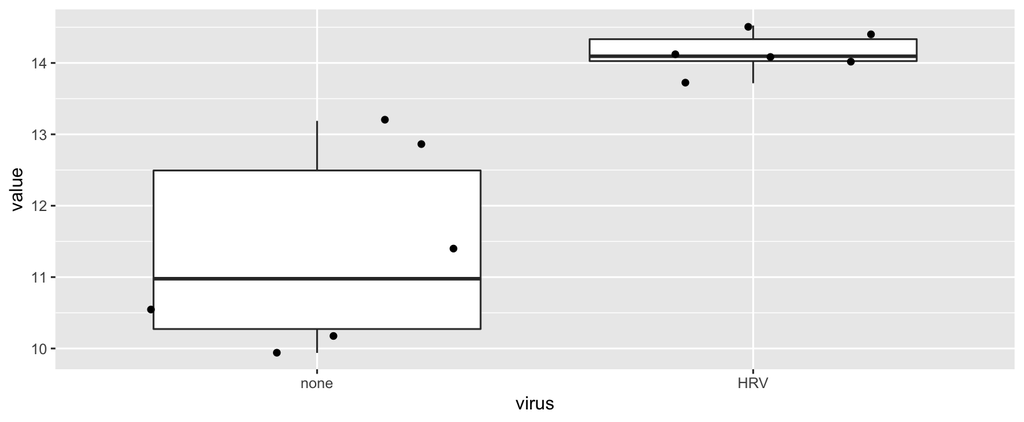

```r
dat %>%
  filter(hgnc_symbol == "IFIT3") %>%

  ggplot(aes(x = virus, y = value)) +
  geom_boxplot(outlier.shape = NA) +
  geom_jitter()
```

Only show some points

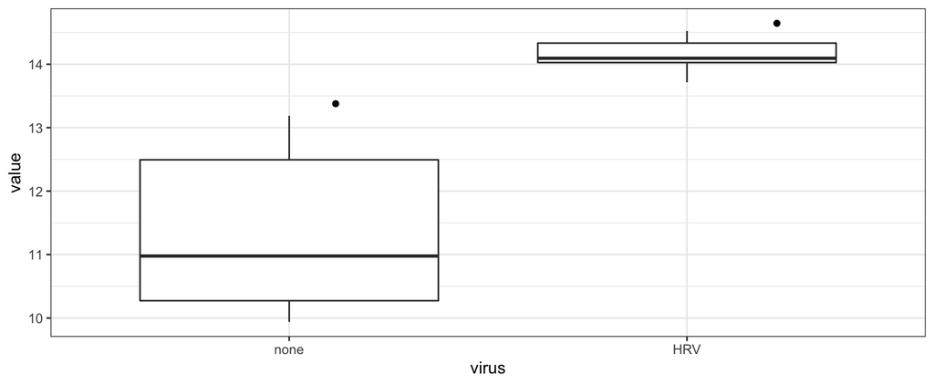

```r
dat %>%
  filter(hgnc_symbol == "IFIT3") %>%

  ggplot(aes(x = virus, y = value)) +
  geom_boxplot(outlier.shape = NA) +
  geom_jitter(data=filter(dat,
                          hgnc_symbol == "IFIT3" & donorID=="donor1")) +
  #theme_classic() +
  theme_bw()
```

See `ggthemes` for more

Save to file

```r
plot1 <- dat %>%
  filter(hgnc_symbol == "IFIT3") %>%

  ggplot(aes(x = virus, y = value)) +
  geom_boxplot(outlier.shape = NA) +
  geom_jitter()

ggsave(filename = "plot1.png", plot1,
       width=3, height=3)
```

Width of boxplot relative to sample size.

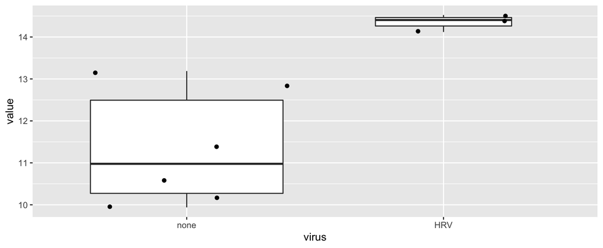

```r
dat %>%
  filter(hgnc_symbol == "IFIT3") %>%
  arrange(virus) %>%
  slice_head(n=9) %>%

  ggplot(aes(x = virus, y = value)) +
  geom_boxplot(varwidth = TRUE,
               outlier.shape = NA) +
  geom_jitter()
```

Violin version with scale to sample size

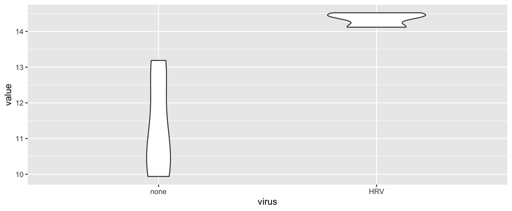

```r
dat %>%
  filter(hgnc_symbol == "IFIT3") %>%
  arrange(virus) %>%
  slice_head(n=9) %>%

  ggplot(aes(x = virus, y = value)) +
  geom_violin(scale = "count")
```

## Barplot

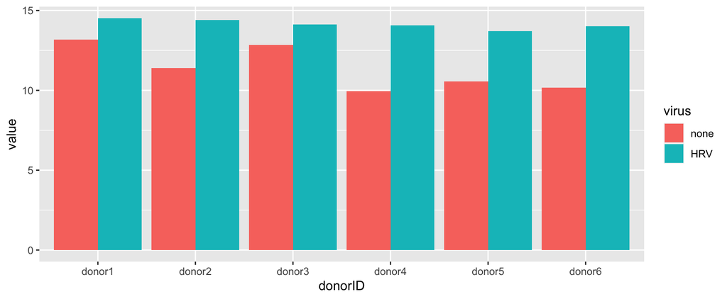

```r
dat %>%
  filter(hgnc_symbol == "IFIT3") %>%

  ggplot(aes(x = donorID, y = value)) +
  geom_bar(aes(fill = virus), stat = "identity",
           position = 'dodge')
```

Stacked bars

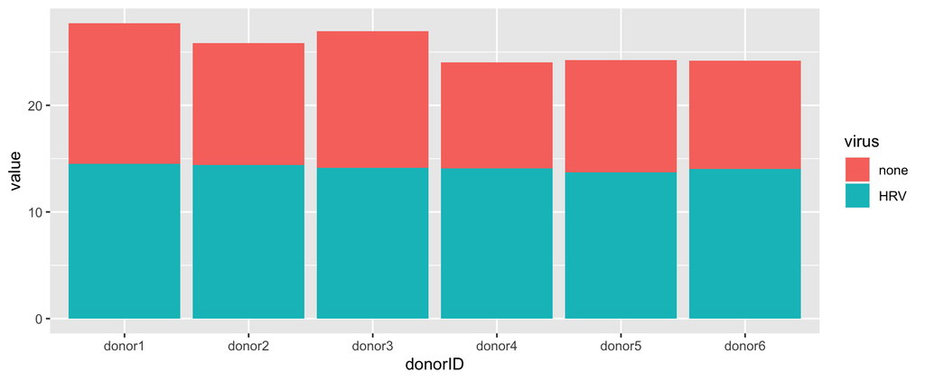

```r
dat %>%
  filter(hgnc_symbol == "IFIT3") %>%

  ggplot(aes(x = donorID, y = value)) +
  geom_bar(aes(fill = virus), stat = "identity")
```

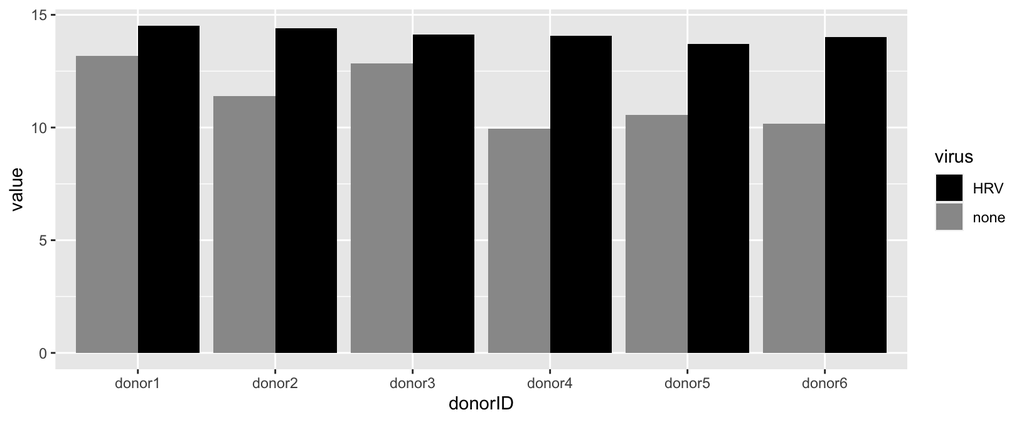

```r
dat %>%
  filter(hgnc_symbol == "IFIT3") %>%

  ggplot(aes(x = donorID, y = value)) +
  geom_bar(aes(fill = virus), stat = "identity",
           position = 'dodge') +
  scale_fill_manual(values = c('HRV'='black',
                               'none'='grey60'))
```

Color ideas at https://colorbrewer2.org/

Plot mean with error

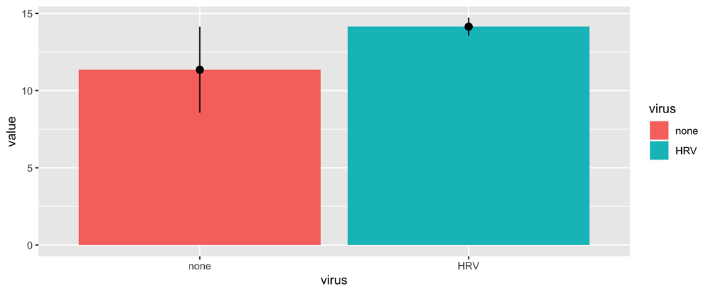

```r
dat %>%
  filter(hgnc_symbol == "IFIT3") %>%

  ggplot(aes(x = virus, y = value)) +
  geom_bar(aes(fill = virus),
           stat = "summary", fun = "mean") +
  stat_summary(fun.data="mean_sdl")
```

## “Lollipop” plot

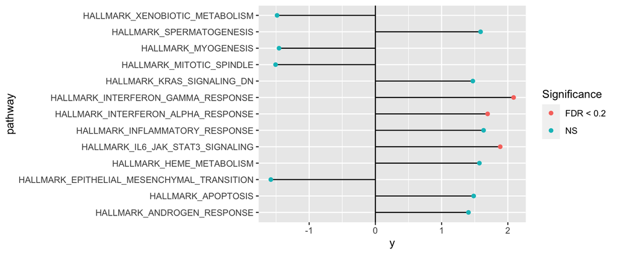

```r
gsea %>%
  filter(padj < 0.3) %>%
  mutate(Significance = ifelse(padj < 0.2, "FDR < 0.2", "NS")) %>%

  ggplot() +
  geom_segment(aes(x=pathway, xend=pathway,
                   y=0, yend=NES)) +
  geom_point(aes(x=pathway, y=NES,
                 color = Significance)) +
  geom_hline(yintercept = 0) +
  coord_flip()
```

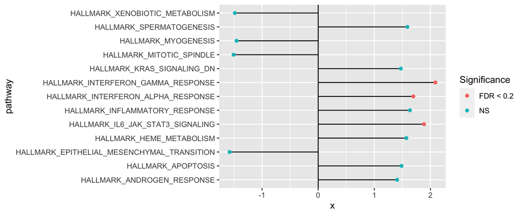

```r
gsea %>%
  filter(padj < 0.3) %>%
  mutate(Significance = ifelse(padj < 0.2, "FDR < 0.2", "NS")) %>%

  ggplot() +
  geom_segment(aes(y=pathway, yend=pathway,
                   x=0, xend=NES)) +
  geom_point(aes(y=pathway, x=NES,
                 color = Significance)) +
  geom_vline(xintercept = 0)
```

Reorder by NES

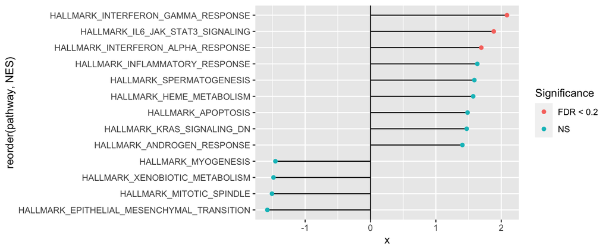

```r
gsea %>%
  filter(padj < 0.3) %>%
  mutate(Significance = ifelse(padj < 0.2, "FDR < 0.2", "NS")) %>%

  ggplot() +
  geom_segment(aes(y=reorder(pathway,NES), yend=reorder(pathway,NES),
                   x=0, xend=NES)) +
  geom_point(aes(y=reorder(pathway,NES), x=NES,
                 color = Significance)) +
  geom_vline(xintercept = 0)
```

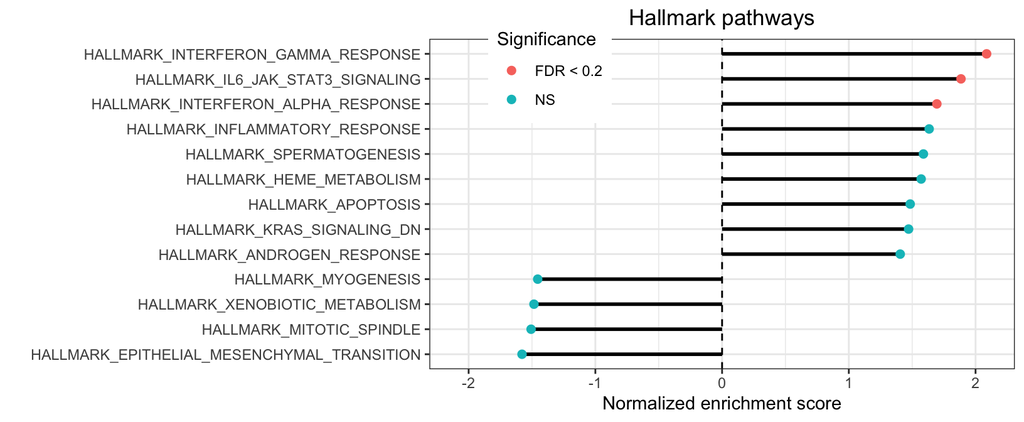

```r
gsea %>%
  filter(padj < 0.3) %>%
  mutate(Significance = ifelse(padj < 0.2, "FDR < 0.2", "NS")) %>%

  ggplot() +
  geom_segment(aes(y=reorder(pathway,NES),
                   yend=reorder(pathway,NES),
                   x=0, xend=NES), size=1) +
  geom_point(aes(y=reorder(pathway,NES), x=NES,
                 color = Significance), size=2) +
  geom_vline(xintercept = 0, lty="dashed") +
  theme_bw() +
  theme(legend.position = c(0.1,0.9),
        legend.direction = "vertical",
        plot.title = element_text(hjust = 0.5),
        legend.justification = "left") +
  labs(x="Normalized enrichment score",
       y="", title="Hallmark pathways") +
  lims(x=c(-2.1,2.1))
```